# R Notebook

```r
library(tidyverse)
library(tidytext)
library(lubridate)
library(ggthemes)
theme_set(theme_light())
# dropping vehicles (duplicate), adding 2000 to the year so it is up to date, making categories for responsibility based on popular 4 then lumping rest, turns out there's Baltimore City and Baltimore city and fixing it,
maryland_bridges <- read_csv("https://raw.githubusercontent.com/rfordatascience/tidytuesday/master/data/2018/2018-11-27/baltimore_bridges.csv") %>% select(-vehicles) %>%
  mutate(inspection_yr = inspection_yr + 2000,
  decade = 10 * (yr_built %/% 10),
  responsibility = fct_lump(responsibility,4),
  county = str_to_title(county))
```

```r
glimpse(maryland_bridges)
```

```
Observations: 2,079
Variables: 13
$ lat                          <dbl> 39.22500, 39.22333, 39.20167, 39.20167, 39.18167, 39.14500, 39.01944, 39.01944, 38.95167, 39....
$ long                         <dbl> -76.66167, -76.65833, -76.63167, -76.63167, -76.61333, -76.60667, -76.50278, -76.50278, -76.5...
$ county                       <chr> "Anne Arundel County", "Anne Arundel County", "Anne Arundel County", "Anne Arundel County", "...
$ carries                      <chr> "IS 695", "IS 695", "IS 695 IL", "IS 695 OL", "MD 2", "MD 2", "MD 2 RAMP 8", "US 50  RAMP 6",...
$ yr_built                     <int> 1958, 1951, 1957, 1957, 1937, 1936, 1953, 1953, 1983, 1949, 1949, 1949, 1990, 1990, 1950, 195...
$ bridge_condition             <chr> "Fair", "Fair", "Fair", "Fair", "Good", "Fair", "Good", "Fair", "Fair", "Fair", "Fair", "Fair...
$ avg_daily_traffic            <int> 128182, 128182, 92102, 92102, 31511, 23961, 20393, 2833, 53221, 13660, 2892, 9020, 7530, 1089...
$ total_improve_cost_thousands <int> NA, 158, 1168, NA, NA, NA, 419, 388, 13504, 222, 220, 266, NA, NA, NA, NA, NA, NA, NA, NA, NA...
$ inspection_mo                <chr> "07", "02", "11", "11", "06", "11", "03", "01", "10", "10", "03", "05", "06", "08", "12", "12...
$ inspection_yr                <dbl> 2016, 2016, 2015, 2015, 2015, 2015, 2016, 2016, 2015, 2016, 2016, 2015, 2015, 2015, 2015, 201...
$ owner                        <chr> "State Highway Agency", "State Highway Agency", "State Highway Agency", "State Highway Agency...
$ responsibility               <fct> State Highway Agency, State Highway Agency, State Highway Agency, State Highway Agency, State...
$ decade                       <dbl> 1950, 1950, 1950, 1950, 1930, 1930, 1950, 1950, 1980, 1940, 1940, 1940, 1990, 1990, 1950, 195...
```

```r
# finding duplicates?
maryland_bridges %>%
  count(lat,long,avg_daily_traffic, sort=T)
```

```
# A tibble: 1,986 x 4
     lat  long avg_daily_traffic     n
   <dbl> <dbl>             <int> <int>
 1  39.3 -76.7             25300     6
 2  39.2 -76.7            176796     3
 3  39.0 -76.7             13992     2
 4  39.0 -76.5            123940     2
 5  39.1 -76.6             39092     2
 6  39.1 -76.8             65902     2
 7  39.1 -76.9            186040     2
 8  39.1 -76.6            135900     2
 9  39.1 -76.6             26792     2
10  39.1 -76.6             12651     2
# ... with 1,976 more rows
```

```r
# counting the grouping varaibles
maryland_bridges %>%
  count(bridge_condition, sort= T)
```

```
# A tibble: 3 x 2
  bridge_condition     n
  <chr>            <int>
1 Fair              1357
2 Good               624
3 Poor                98
```

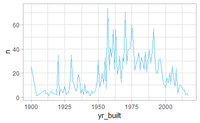

```r
# basic time series
maryland_bridges %>%
  filter(yr_built >= 1900) %>%
  count(yr_built, sort= T) %>%
  ggplot(aes(x=yr_built,y=n)) +
  geom_line()
```

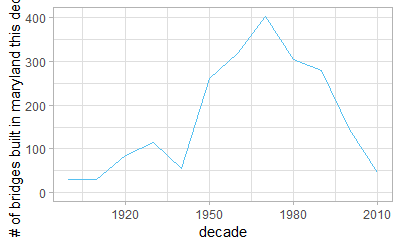

```r
# truncating by decade
maryland_bridges %>%
  filter(yr_built >= 1900) %>%
  count(decade, sort= T) %>%
  ggplot(aes(x=decade,y=n)) +
  geom_line() +
  expand_limits(y=0) +
  labs(y= '# of bridges built in maryland this decade')
```

How does the condition of bridges depend on when it was built?

```r
# first look, need to add filter
maryland_bridges %>%
  group_by(decade) %>%
  summarize(pct_good = mean(bridge_condition == "Good"),
            total = n())
```

```
# A tibble: 17 x 3
   decade pct_good total
    <dbl>    <dbl> <int>
 1   1800   0          1
 2   1860   1          1
 3   1870   0          1
 4   1880   0          4
 5   1890   0          4
 6   1900   0.103     29
 7   1910   0.103     29
 8   1920   0.0824    85
 9   1930   0.0526   114
10   1940   0.0909    55
11   1950   0.0651   261
12   1960   0.113    319
13   1970   0.153    404
14   1980   0.372    304
15   1990   0.706    279
16   2000   0.903    144
17   2010   0.978     45
```

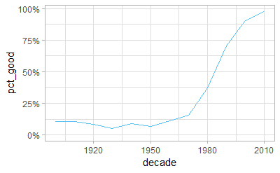

```r
library(scales)
maryland_bridges %>%
  filter(yr_built >= 1900) %>%
  group_by(decade) %>%
  summarize(pct_good = mean(bridge_condition == "Good"),
            total = n()) %>%
  ggplot(aes(decade, pct_good)) +
  geom_line() +
  scale_y_continuous(labels = percent_format()) +
  expand_limits(y=0)
```

Most bridges built before 1970, we woud not consider in “good” condition (although it doesnt matter how long before 1970 they were built), while a majority of bridges built since 2000 are in Good condition.

# are both these columns the same or which should we choose?

```r
# usually the same, responsibility is better
maryland_bridges %>%
  count(owner, responsibility, sort =T)
```

```
# A tibble: 14 x 3
   owner                            responsibility                       n
   <chr>                            <fct>                            <int>
 1 State Highway Agency             State Highway Agency               913
 2 County Highway Agency            County Highway Agency              676
 3 State Toll Authority             State Toll Authority               230
 4 City or Municipal Highway Agency City or Municipal Highway Agency   215
 5 Other State Agencies             Other                               17
 6 Army                             Other                                8
 7 National Park Service            Other                                7
 8 Private (other than railroad)    State Highway Agency                 3
 9 Town or Township Highway Agency  Other                                3
10 Navy/Marines                     Other                                2
11 NA                               NA                                   2
12 Other Local Agencies             County Highway Agency                1
13 Private (other than railroad)    Other                                1
14 State Toll Authority             City or Municipal Highway Agency     1
```

```r
# see which don't match
maryland_bridges %>%
  filter(owner != responsibility) %>%
  count(owner, responsibility, sort =T)
```

```
# A tibble: 9 x 3
  owner                           responsibility                       n
  <chr>                           <fct>                            <int>
1 Other State Agencies            Other                               17
2 Army                            Other                                8
3 National Park Service           Other                                7
4 Private (other than railroad)   State Highway Agency                 3
5 Town or Township Highway Agency Other                                3
6 Navy/Marines                    Other                                2
7 Other Local Agencies            County Highway Agency                1
8 Private (other than railroad)   Other                                1
9 State Toll Authority            City or Municipal Highway Agency     1
```

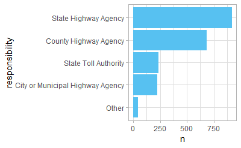

```r
# fix na and select 4 most popular, in order
maryland_bridges %>%
  replace_na(list(responsibility = "Other")) %>%
  count(responsibility, sort =T) %>%
  mutate(responsibility = fct_reorder(responsibility,n)) %>%
  ggplot(aes(responsibility,n)) +
  geom_col() +
  coord_flip()
```

```r
#looking at agencies and who built successful bridges
maryland_bridges %>%
  filter(yr_built >=1900) %>%
  replace_na(list(responsibility = "Other")) %>%
  group_by(responsibility,
        decade) %>%
  summarize(pct_good = mean(bridge_condition == "Good"),
            total = n())
```

| responsibility | decade | pct_good | total |
| --- | --- | --- | --- |
| City or Municipal Highway Agency | 1900 | 0.00000000 | 9 |
| City or Municipal Highway Agency | 1910 | 0.00000000 | 10 |
| City or Municipal Highway Agency | 1920 | 0.05882353 | 17 |
| City or Municipal Highway Agency | 1930 | 0.03448276 | 29 |
| City or Municipal Highway Agency | 1940 | 0.00000000 | 1 |
| City or Municipal Highway Agency | 1950 | 0.05128205 | 39 |
| City or Municipal Highway Agency | 1960 | 0.10526316 | 38 |
| City or Municipal Highway Agency | 1970 | 0.08571429 | 35 |
| City or Municipal Highway Agency | 1980 | 0.25000000 | 12 |
| City or Municipal Highway Agency | 1990 | 0.69230769 | 13 |

[output cut: 42 more lines]

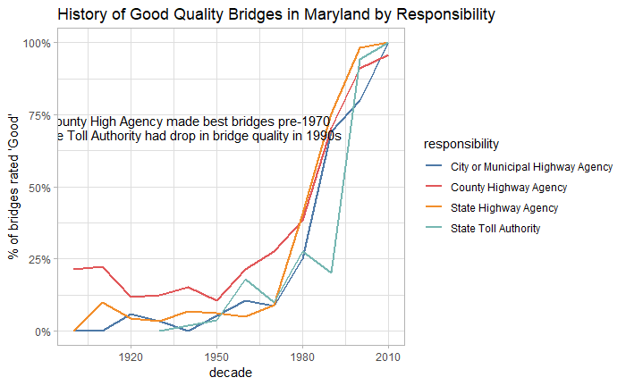

```r
maryland_bridges %>%
  filter(yr_built >=1900) %>%
  replace_na(list(responsibility = "Other")) %>%
  group_by(responsibility,
        decade) %>%
  summarize(pct_good = mean(bridge_condition == "Good"),
            total = n()) %>%
  filter(responsibility != "Other") %>%
  ggplot(aes(decade,pct_good, color = responsibility)) +
  geom_line(size = 1) +

  scale_y_continuous(labels = percent_format()) +
  scale_color_manual(values = c("#4E79A7","#E15759", "#F28E2B", "#76B7B2")) +
  expand_limits(y=0) +
    annotate("text", x=1940, y= 0.73, label = "County High Agency made best bridges pre-1970", color = "black") +
  annotate("text", x=1940, y= 0.68, label = "State Toll Authority had drop in bridge quality in 1990s", color = "black") +
  labs(title = 'History of Good Quality Bridges in Maryland by Responsibility', y="% of bridges rated 'Good'")
```

County High Agency starts better than most before 1970 State Toll Authority has bad bridges in 1990s

# avg_daily_traffic

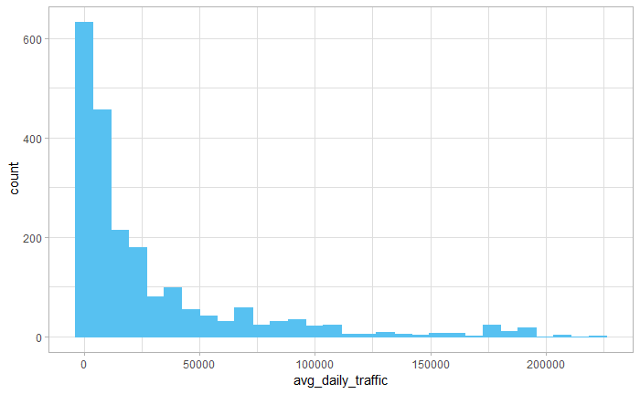

```r
# first look, has a bad distribution,
maryland_bridges %>%
  ggplot(aes(x=avg_daily_traffic)) +
  geom_histogram()
```

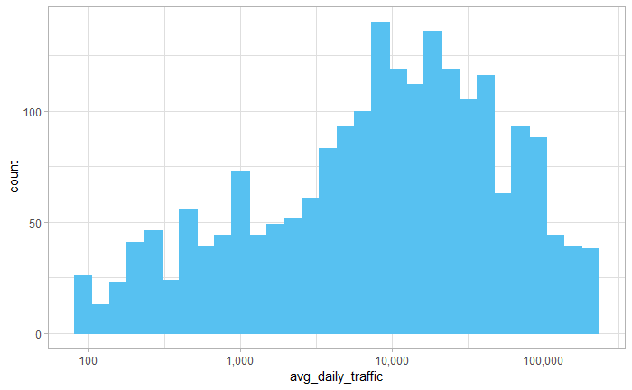

```r
# switch to log scale, makes decent categoies 100-1000, 1000-10000 etc..
maryland_bridges %>%
  ggplot(aes(x=avg_daily_traffic)) +
  geom_histogram() +
  scale_x_log10(labels = comma_format())
```

```r
# see perecent of good by categories, not too much different
maryland_bridges %>%
  filter(yr_built >= 1990) %>%
  group_by(traffic_category = cut(avg_daily_traffic, c(0,1000,10000, Inf),labels = c("<1000", "1000-10,000", "10,000+"))) %>%
  summarize(pct_good = mean(bridge_condition == "Good"),
            total = n())
```

```
# A tibble: 3 x 3
  traffic_category pct_good total
  <fct>               <dbl> <int>
1 <1000               0.758    91
2 1000-10,000         0.811   159
3 10,000+             0.794   218
```

```r
# looking at older bridges
maryland_bridges %>%
  filter(yr_built < 1990) %>%
  group_by(traffic_category = cut(avg_daily_traffic, c(0,1000,10000, Inf),labels = c("<1000", "1000-10,000", "10,000+"))) %>%
  summarize(pct_good = mean(bridge_condition == "Good"),
            total = n())
```

```
# A tibble: 3 x 3
  traffic_category pct_good total
  <fct>               <dbl> <int>
1 <1000               0.239   259
2 1000-10,000         0.156   520
3 10,000+             0.132   832
```

# make a map

[figure not shown]

```r
maryland_bridges %>%
  filter(yr_built >=1900) %>%
  group_by(county,
        decade) %>%
  summarize(pct_good = mean(bridge_condition == "Good"),
            total = n()) %>%
  arrange(county, decade)
```

| county | decade | pct_good | total |
| --- | --- | --- | --- |
| Anne Arundel County | 1920 | 0.00000000 | 1 |
| Anne Arundel County | 1930 | 0.11111111 | 9 |
| Anne Arundel County | 1940 | 0.00000000 | 15 |
| Anne Arundel County | 1950 | 0.09302326 | 43 |
| Anne Arundel County | 1960 | 0.10344828 | 29 |
| Anne Arundel County | 1970 | 0.12820513 | 39 |
| Anne Arundel County | 1980 | 0.42000000 | 50 |
| Anne Arundel County | 1990 | 0.70535714 | 112 |
| Anne Arundel County | 2000 | 0.72727273 | 22 |
| Anne Arundel County | 2010 | 1.00000000 | 3 |

[output cut: 60 more lines]

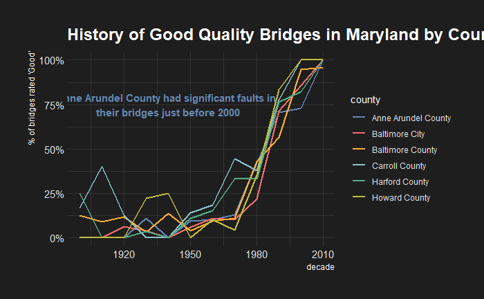

```r
# hard to conclude much
maryland_bridges %>%
  filter(yr_built >=1900) %>%
  group_by(county,
        decade) %>%
  summarize(pct_good = mean(bridge_condition == "Good"),
            total = n()) %>%
  arrange(county, decade) %>%
  ggplot(aes(decade,pct_good, color = county)) +
  geom_line(size = 1) +
  hrbrthemes::theme_modern_rc() +
  scale_y_continuous(labels = percent_format()) +
  scale_color_manual(values =  c("#6388b4", "#ef6f6a", "#ffae34", "#8cc2ca", "#55ad89", "#c3bc3f")) +
  expand_limits(y=0) +
  labs(title = 'History of Good Quality Bridges in Maryland by County', y="% of bridges rated 'Good'") +
  annotate("text", x=1940, y=0.75, label = "Anne Arundel County had significant faults in \ntheir bridges just before 2000", colour = "#6388b4", fontface = "bold")
```

[figure not shown]

### Effect of county, traffic, and responsibility and time on bridge condition

[figure not shown]

[figure not shown]

[figure not shown]

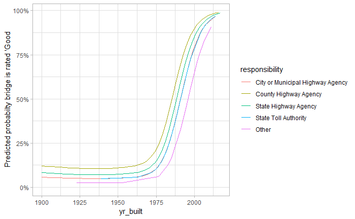

```r
# add a new variable
bridges<- bridges %>%
mutate(good = bridge_condition == "Good") %>%
drop_na(responsibility)
model4 <- glm(good ~ ns(yr_built, 4) + responsibility, data = bridges, family = "binomial")
augment(model4, bridges, type.predict = "response") %>%
  ggplot(aes(yr_built, .fitted, colour = responsibility)) +
  geom_line() +
  expand_limits(y=0) +
labs(y="Predicted probabilty bridge is rated 'Good") +
  scale_y_continuous(labels = percent_format())
```

```r
# county highway agency is best to be good, but most uninterpretable
summary(model4)
```

```
Call:
glm(formula = good ~ ns(yr_built, 4) + responsibility, family = "binomial",
    data = bridges)

Deviance Residuals:
    Min       1Q   Median       3Q      Max
-2.7747  -0.5201  -0.4015   0.3894   2.4560

Coefficients:
                                    Estimate Std. Error z value             Pr(>|z|)
(Intercept)                         -2.81234    0.52996  -5.307          0.000000112 ***
ns(yr_built, 4)1                     0.17789    0.47796   0.372              0.70976
ns(yr_built, 4)2                     3.17876    0.38088   8.346 < 0.0000000000000002 ***
ns(yr_built, 4)3                     5.00450    1.17174   4.271          0.000019459 ***
ns(yr_built, 4)4                     6.86498    0.67426  10.182 < 0.0000000000000002 ***
responsibilityCounty Highway Agency  0.82801    0.26270   3.152              0.00162 **
responsibilityState Highway Agency   0.38534    0.26012   1.481              0.13850
responsibilityState Toll Authority  -0.01136    0.32613  -0.035              0.97222
responsibilityOther                 -0.73465    0.48884  -1.503              0.13288
---
Signif. codes:  0 ‘***’ 0.001 ‘**’ 0.01 ‘*’ 0.05 ‘.’ 0.1 ‘ ’ 1

(Dispersion parameter for binomial family taken to be 1)

    Null deviance: 2527.8  on 2065  degrees of freedom
Residual deviance: 1651.2  on 2057  degrees of freedom
AIC: 1669.2

Number of Fisher Scoring iterations: 5
```